# Indel Signature InsDel1c

# InsDel1c

(corresponds to 83-type signature C_ID1)

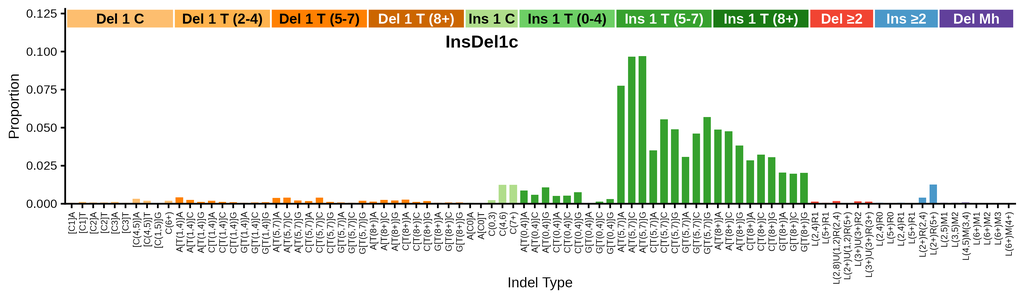

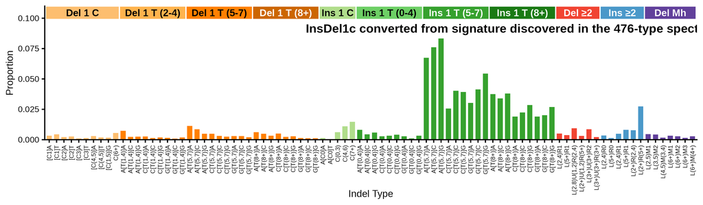

89-type spectrum of the linking tumor SP112907 | cosine similarity to InsDel1c: 0.9675

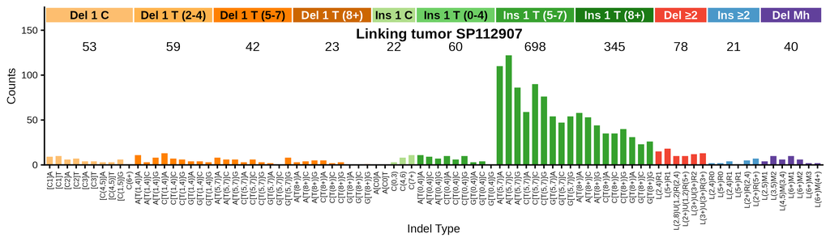

**Click to view decomposition of the linking tumor spectrum**

Partial mutation signature of SP112907 due to InsDel1c

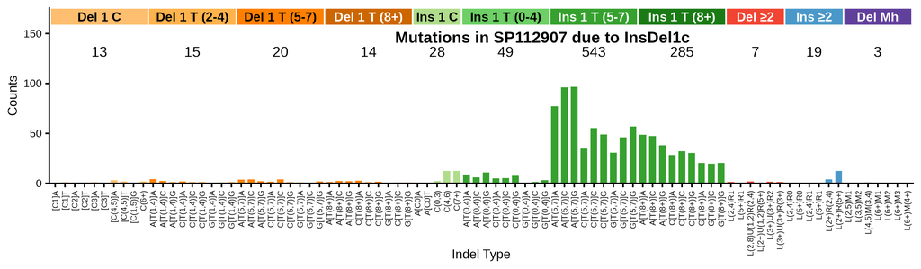

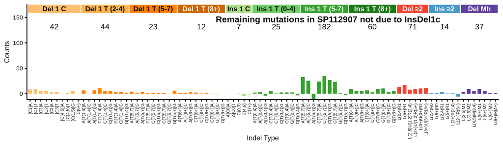

Max neg fraction (maximum allowed negative residual count as fraction of total): 0.03  
N subtract (mutation count assigned to signature): 996.3  
N residual (mutation count in residual “partial spectrum”): 444.7  
Total negative (sum of negative residual mutation counts): 36.0  
N negative channels (number of channels with negative residual): 14  
P(≥ total negative) (Monte Carlo estimated probability that negative-binomial-sampled spectra from the signature contributing N subtract mutations would produce a total negative count >= the observed Total negative; higher number means not surprising): 0.936

**Per-channel residual breakdown**

| Channel | Spectrum | Sig_Count | Residual | Sig_Prop |
| --- | --- | --- | --- | --- |
| [Del(C):R1]A | 9 | 0.7 | 8.3 | 0.00069 |
| [Del(C):R1]T | 10 | 1.2 | 8.8 | 0.00125 |
| [Del(C):R2]A | 6 | 0.9 | 5.1 | 0.00093 |
| [Del(C):R2]T | 7 | 0.9 | 6.1 | 0.00090 |
| [Del(C):R3]A | 4 | 1.2 | 2.8 | 0.00116 |
| [Del(C):R3]T | 4 | 0.7 | 3.3 | 0.00071 |
| [Del(C):R(4,5)]A | 3 | 3.3 | -0.3 | 0.00334 |
| [Del(C):R(4,5)]T | 3 | 1.9 | 1.1 | 0.00188 |
| [Del(C):R(1,5)]G | 6 | 0.4 | 5.6 | 0.00044 |
| Del(C):R(6,9) | 1 | 1.9 | -0.9 | 0.00196 |
| A[Del(T):R(1,4)]A | 11 | 4.3 | 6.7 | 0.00427 |
| A[Del(T):R(1,4)]C | 3 | 2.5 | 0.5 | 0.00249 |
| A[Del(T):R(1,4)]G | 8 | 1.2 | 6.8 | 0.00120 |
| C[Del(T):R(1,4)]A | 13 | 2.0 | 11 | 0.00200 |
| C[Del(T):R(1,4)]C | 7 | 1.3 | 5.7 | 0.00129 |
| C[Del(T):R(1,4)]G | 6 | 1.0 | 5 | 0.00105 |
| G[Del(T):R(1,4)]A | 4 | 0.7 | 3.3 | 0.00074 |
| G[Del(T):R(1,4)]C | 4 | 0.9 | 3.1 | 0.00087 |
| G[Del(T):R(1,4)]G | 3 | 1.1 | 1.9 | 0.00110 |
| A[Del(T):R(5,7)]A | 8 | 3.8 | 4.2 | 0.00377 |
| A[Del(T):R(5,7)]C | 6 | 4.0 | 2 | 0.00398 |
| A[Del(T):R(5,7)]G | 6 | 2.2 | 3.8 | 0.00223 |
| C[Del(T):R(5,7)]A | 3 | 1.7 | 1.3 | 0.00174 |
| C[Del(T):R(5,7)]C | 6 | 3.9 | 2.1 | 0.00396 |
| C[Del(T):R(5,7)]G | 3 | 1.2 | 1.8 | 0.00122 |
| G[Del(T):R(5,7)]A | 2 | 0.8 | 1.2 | 0.00081 |
| G[Del(T):R(5,7)]C | 0 | 0.6 | -0.6 | 0.00060 |
| G[Del(T):R(5,7)]G | 8 | 1.9 | 6.1 | 0.00189 |
| A[Del(T):R(8,)]A | 3 | 1.5 | 1.5 | 0.00148 |
| A[Del(T):R(8,)]C | 4 | 2.6 | 1.4 | 0.00257 |

[output cut: 59 more lines]

**Click to view similar signatures from Koh et al.**

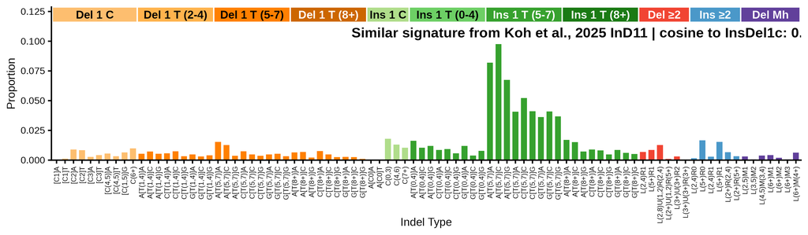

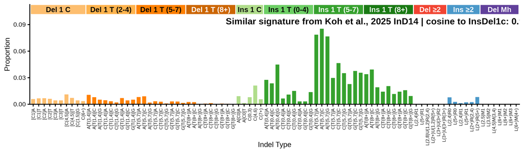

## 476-type representations corresponding to InsDel1c

Extracted 476-type signature corresponding to InsDel1c

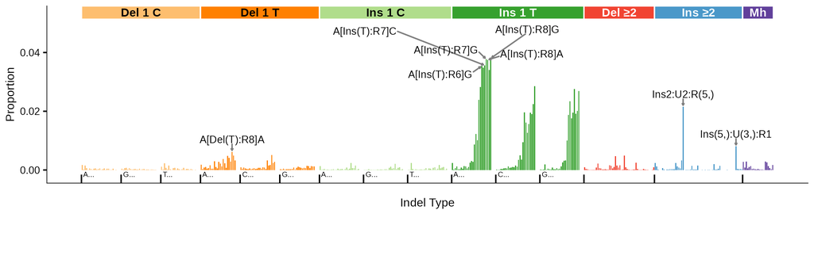

476-type spectrum of the linking tumor SP112907; cosine similarity to the extracted 476-type signature is 0.9009

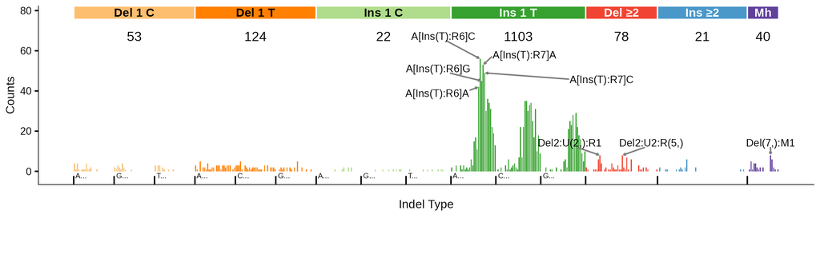

476-type spectrum of best 476-type matching tumor SP125809; cosine similarity to the extracted 476-type signature is 0.9082

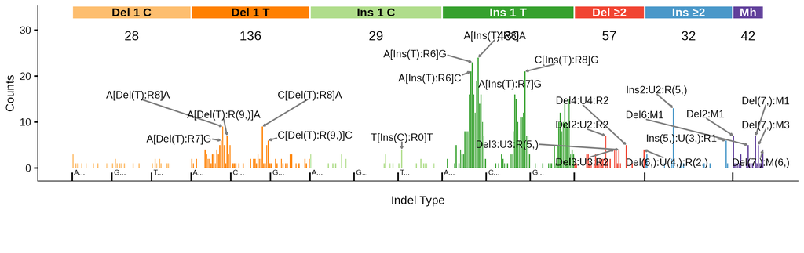

## 83-type signature corresponding to InsDel1c (C_ID1)

**Note**

89-type and 476-type extractions of InsDel1a, 1b, 1c, and 1d all collapse to profiles very similar to C_ID1, with the only slight exception being InsDel1b, which has about 8% T insertion in long poly-T contexts, which C_ID1 lacks.

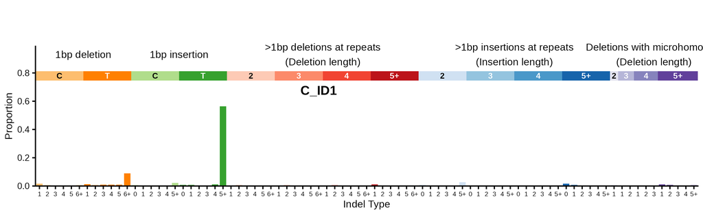

**Click here to see with insertions and deletions of T in long poly-T suppressed**

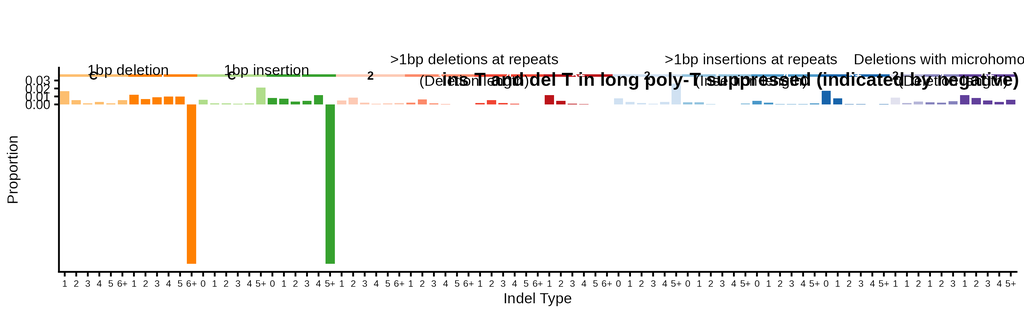

83-type signature converted from signature discovered in the 476-type spectra (using bipartite matching optimization) | cosine similarity to C_ID1: 0.9963

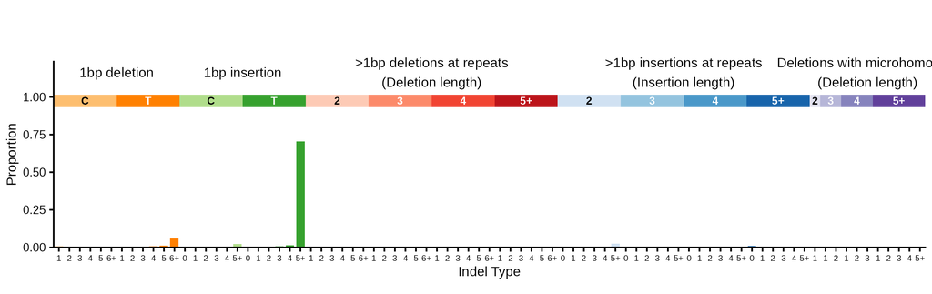

**Click here to see with insertions and deletions of T in long poly-T suppressed**

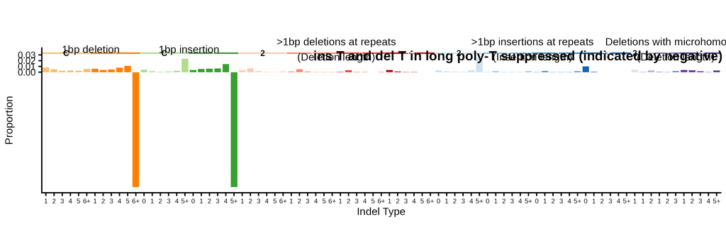

**Click to see flow diagrams: 476-type to 83-type collapse**

These Sankey diagrams show how the 476-type mutation categories are redistributed to 83-type categories using bipartite matching. We only show the diagrams for insertions or deletions of > 1 base because it is for these indels that 476-type categories map to > 1 83-type category.

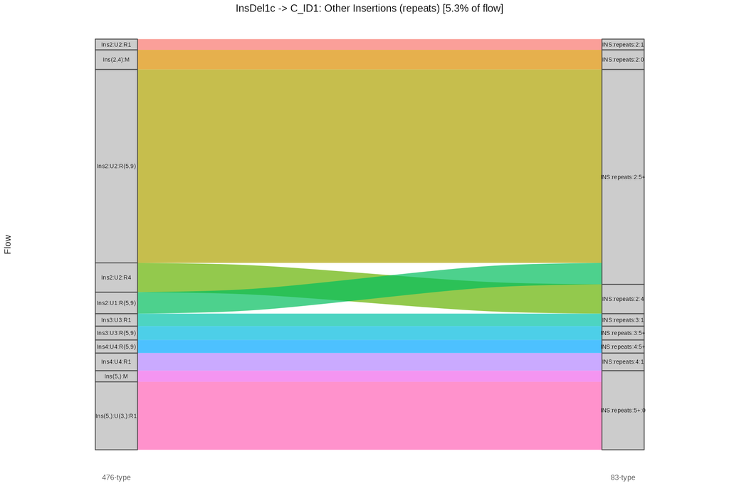

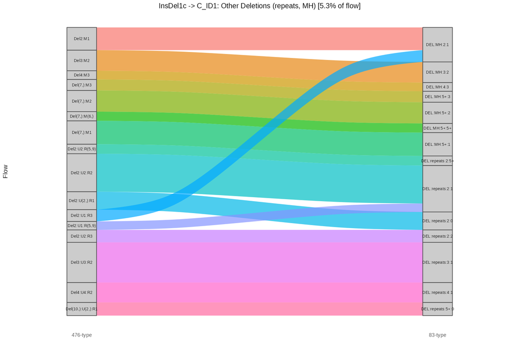

83-type spectrum of the linking tumor SP112907 | cosine similarity to C_ID1: 0.9915

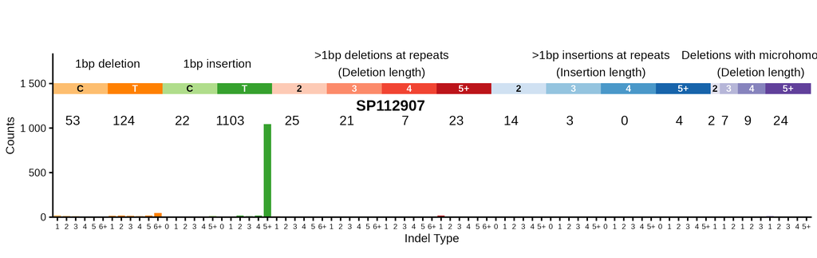

**Click here to see with insertions and deletions of T in long poly-T suppressed**

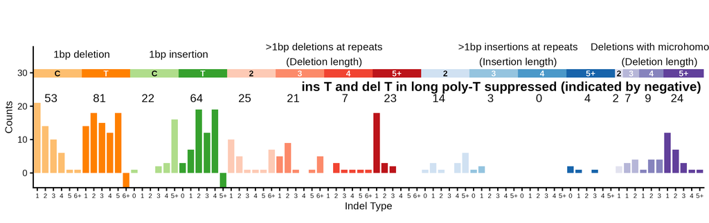

83-type spectrum of best 83-type matching tumor SP107784 | cosine similarity to C_ID1: 0.9986

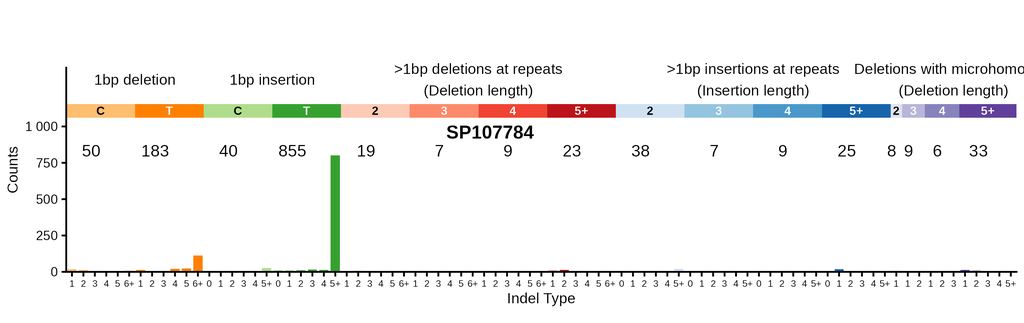

**Click here to see with insertions and deletions of T in long poly-T suppressed**

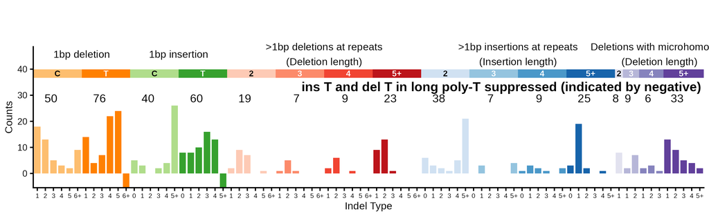

### Similar COSMIC signatures

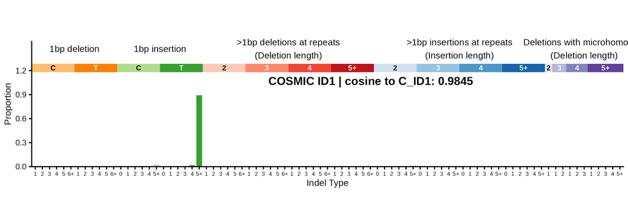

**Click here to see with insertions and deletions of T in long poly-T suppressed**

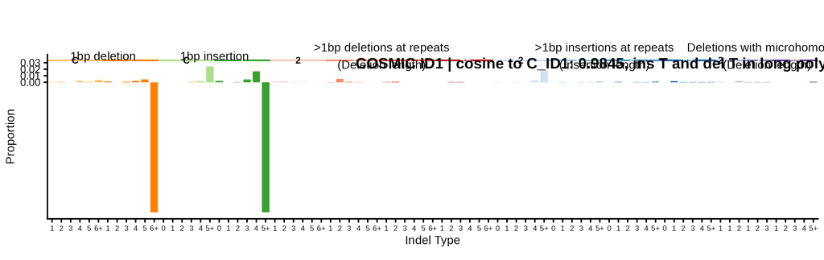

### Similar signatures from Jin et al. 2024

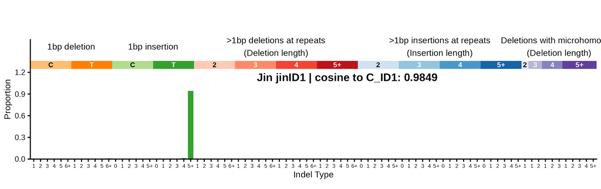

**Click here to see with insertions and deletions of T in long poly-T suppressed**

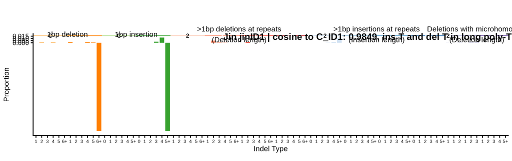